# Spatial Models

Let’s now examine our spatial map of richness and this time focus on the residuals of our model. Do they still look spatially structured?

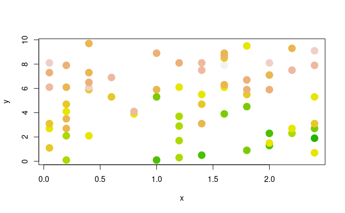

```r
col_brks <- hist(residuals(sr_exp_nug), plot=F)$breaks
col_indices <- as.numeric(cut(residuals(sr_exp_nug), col_brks))
cols <- rev(terrain.colors(length(col_brks)))
plot(mite.xy, cex=2, pch=19, col=cols[col_indices])
```

It does appear that they do still look spatially structured at least at large distances, it is difficult to tell at short distances.

Exercise: Include the variable `WatrCont` along with `SubsDens` in the linear model of richness. Go back through the spatial modeling routines. Does the map of the residuals still seem to show the strong pattern of non-stationary?

Now let’s examine spatial dependence in multivariate response such as species composition in a modeling framework

```r
mite_rda <- rda(mite, mite.env[ , 1:2])

plot(mite_rda, display=c('sp', 'bp'))
anova(mite_rda)
```

```
Permutation test for rda under reduced model
Permutation: free
Number of permutations: 999

Model: rda(X = mite, Y = mite.env[, 1:2])
         Df Variance      F Pr(>F)
Model     2   1977.8 9.3048  0.005 **
Residual 67   7120.8
---
Signif. codes:  0 ‘***’ 0.001 ‘**’ 0.01 ‘*’ 0.05 ‘.’ 0.1 ‘ ’ 1
```

```r
mite_mso_raw <- mso(rda(mite), mite.xy, permutations = 1000)
mite_mso <- mso(mite_rda, mite.xy, permutations = 1000)
mite_mso
```

```
Call: mso(object.cca = mite_rda, object.xy = mite.xy, permutations = 1000)

                Inertia Proportion Rank
Total         9098.5913     1.0000
Constrained   1977.8327     0.2174    2
Unconstrained 7120.7586     0.7826   35
Inertia is variance

Eigenvalues for constrained axes:
  RDA1   RDA2
1919.3   58.6

Eigenvalues for unconstrained axes:
 PC1  PC2  PC3  PC4  PC5  PC6  PC7  PC8
6252  289  153  112   92   57   41   30
(Showing 8 of 35 unconstrained eigenvalues)

mso variogram:
```

|  | H | Dist | n | All | Sum | CA | CCA | se | CA.signif |
| --- | --- | --- | --- | --- | --- | --- | --- | --- | --- |
| 0 | 0 | 0.3555208 | 63 | 69.94617 | 80.83007 | 69.23433 | 11.59574 | 54.81326 | 0.476523477 |
| 1 | 1 | 1.0659051 | 393 | 105.29428 | 108.30363 | 91.67297 | 16.63066 | 27.78515 | 0.664335664 |
| 2 | 2 | 2.0089039 | 534 | 65.74129 | 74.67235 | 56.92943 | 17.74292 | 16.08275 | 0.008991009 |
| 3 | 3 | 2.9786064 | 417 | 127.65530 | 127.35806 | 100.77840 | 26.57966 | 27.10393 | 0.937062937 |
| 4 | 4 | 3.9816823 | 322 | 132.19795 | 133.52256 | 100.77037 | 32.75219 | 31.31581 | 0.943056943 |
| 5 | 5 | 5.0203881 | 245 | 141.72029 | 148.28090 | 105.64335 | 42.63755 | 39.07486 | 0.913086913 |
| 10 | 10 | 6.8069304 | 441 | 242.71228 | 223.33026 | 177.05606 | 46.27420 | 39.86008 | 0.117882118 |

```
Permutation: free
Number of permutations: 1000
```

[figure not shown]

```r
par(mfrow=c(1,1))
```

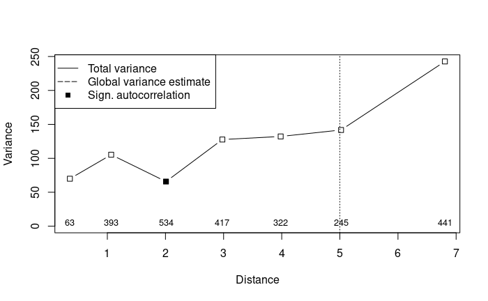

```r
msoplot(mite_mso_raw)
```

```
Error variance of regression model underestimated by 11.3 percent
```

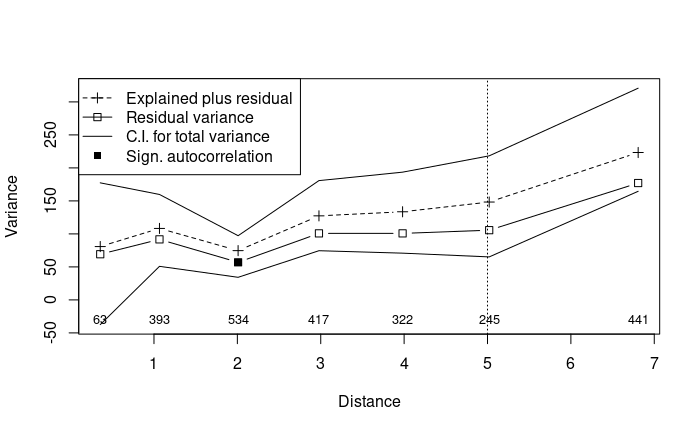

```r
msoplot(mite_mso)
```

## Literature Cited

- Pinheiro, J, and D.M. Bates. 2000. Mixed-Effects Models in S and S-PLUS. Springer. New York, NY, USA.
- Crawley, M. 2014. The R Book, 2nd ed. Wiley, New York.
- Cressie, N.A.C. 1993. Statistics for Spatial Data, Wiley, New York.